# 624: ARIMA

# 6 Hyndman: Exercise 9.7

**Consider aus_airpassengers, the total number of passengers (in millions) from Australian air carriers for the period 1970-2011.**

**Use ARIMA() to find an appropriate ARIMA model. What model was selected. Check that the residuals look like white noise. Plot forecasts for the next 10 periods.**

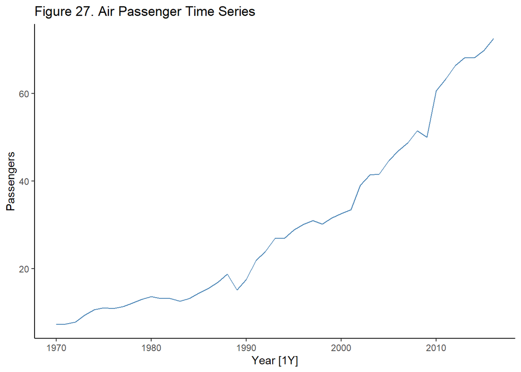

```r
library(forecast)

air<-aus_airpassengers

air%>%
  autoplot(color='steelblue')+
  labs(title = 'Figure 27. Air Passenger Time Series')+
  theme_classic()
```

```r
#perform check on model, we reference back to this

auto<-auto.arima(air)  # results in ARIMA(0,2,1) coeff ma1 = -8.963, s.e. .0594
```

*The passenger time series shows an increasing trend with some curvature. There are no signs of seasonality. The series is not stationary. Differencing will be required to establish the latter.*

*It appears that a second order differencing will be required to achieve stationarity. Stationarity is indicated by the ACF and PACF plots on the second order differenced series (Figure 28).*

```r
air%>%
  features(Passengers, unitroot_ndiffs)%>%
  flextable()%>%
  set_caption('Table 4. Air Passengers: Unitroot Test')
```

Table 4. Air Passengers: Unitroot Test

| ndiffs |
| --- |
| 2 |

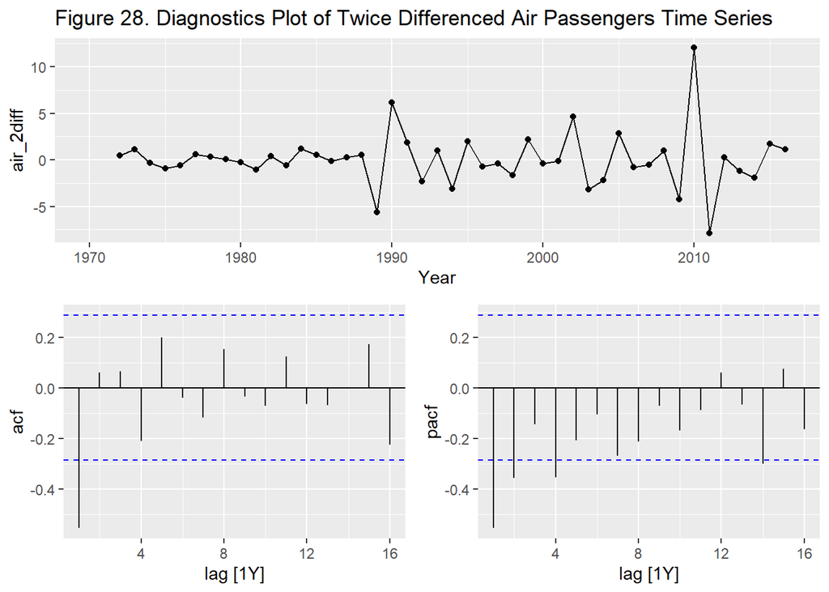

```r
# model single difference and plot diagnostics

air.diff2<-air%>%
  mutate(air_2diff = difference(difference((Passengers))))

air.diff2 %>%
  select(!c(Passengers))%>%
  gg_tsdisplay()+
  labs(title='Figure 28. Diagnostics Plot of Twice Differenced Air Passengers Time Series')
```

*The negative value at lag-1 suggests an MA(1) model or ARIMA (0,2,1) (Figure 28). The PACF is suggestive of an AR(4) or ARIMA (4,2,0) model. Both will be fit and compared along with stepwise and full search ARIMAs.*

*The stepwise and full search models yielded the lowers AICc values and identical results. The best fit model is an ARIMA(0,2,1) with a MA coeff of -0.8963.*

```r
# select model from set of options

air.fit<-air%>%
  model(arima021 = ARIMA(Passengers ~ pdq(0,2,1)),
        arima420 =ARIMA(Passengers ~ pdq(4,2,0)),
        stepwise=ARIMA(Passengers),
        search=ARIMA(Passengers, stepwise=FALSE))


# Review diagnostics

report(air.fit)
```

| .model | sigma2 | log_lik | AIC | AICc | BIC | ar_roots | ma_roots |
| --- | --- | --- | --- | --- | --- | --- | --- |
| arima021 | 4.307764 | -97.01896 | 198.0379 | 198.3236 | 201.6512 |  |  |
| arima420 | 4.857715 | -97.91204 | 205.8241 | 207.3625 | 214.8574 |  |  |
| stepwise | 4.307764 | -97.01896 | 198.0379 | 198.3236 | 201.6512 |  |  |
| search | 4.307764 | -97.01896 | 198.0379 | 198.3236 | 201.6512 |  |  |

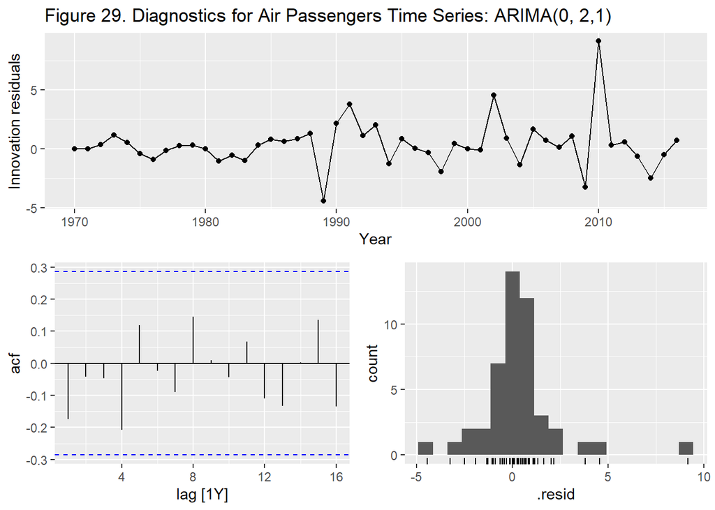

```r
# plot model diagnostics

air.fit%>%
  select(search)%>%
  gg_tsresiduals()+
  labs(title='Figure 29. Diagnostics for Air Passengers Time Series: ARIMA(0, 2,1)')
```

```r
# get Beta coefficient along with full model results

coeff<-air.diff2%>%model(ARIMA(Passengers))%>%
  tidy(report())  # full search

coeff%>%flextable()%>%
  set_caption('Table 5: ARIMA(0,2,1) Statistics')
```

Table 5: ARIMA(0,2,1) Statistics

| .model | term | estimate | std.error | statistic | p.value |
| --- | --- | --- | --- | --- | --- |
| ARIMA(Passengers) | ma1 | -0.8962564 | 0.05941695 | -15.08419 | 0.0000000000000000003240865 |

*The 10 year forecast using ARIMA(0,2,1).*

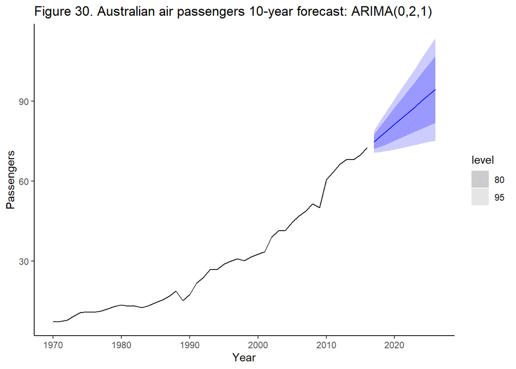

```r
air.fit%>%
  forecast(h = 10) %>%
  filter(.model=='search')%>%
  autoplot(air) +
  labs(title = 'Figure 30. Australian air passengers 10-year forecast: ARIMA(0,2,1)')+
  theme_classic()
```

**Write the model in terms of the backshift operator.**

*General form for a twice differenced series*: $(1-B)^2y_{t}$ = c + $(1+\theta_{1}B+.....\theta_{q}B^{q})\epsilon_{t}$

**Plot forecasts from an ARIMA(0,1,0) model with drift and compare these to part a.**

*Adding a constant (drift) produces a forecast that is shifted downward (shallower slope) relative to part a.*

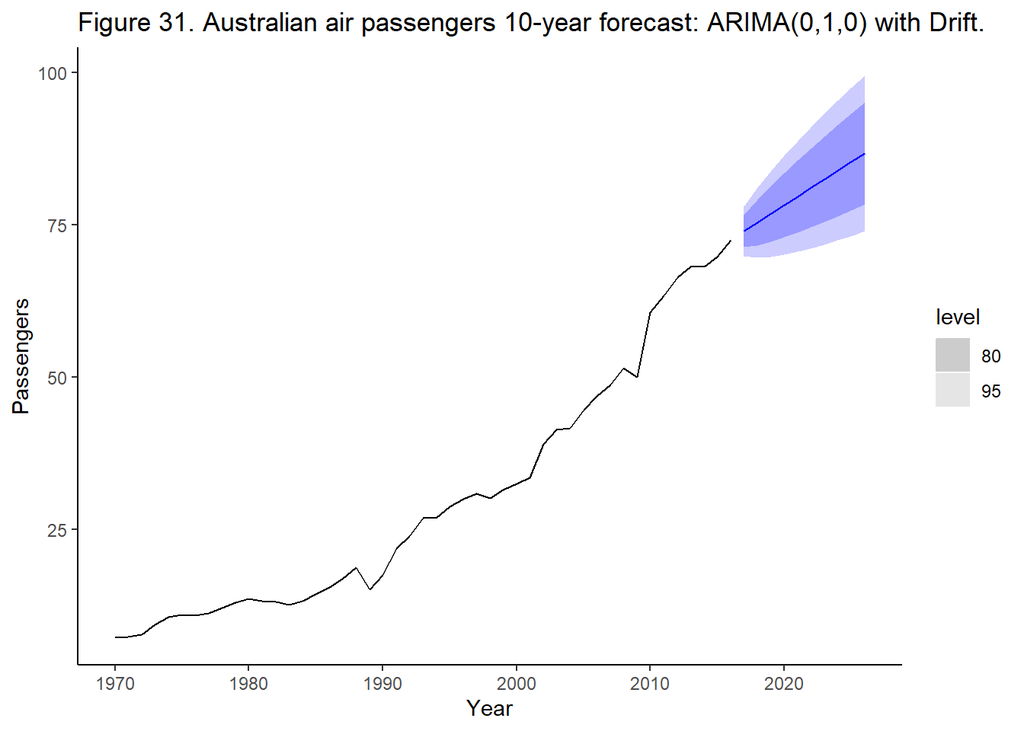

```r
air010.drift<-air%>%
  model(arima010 = ARIMA(Passengers ~ 1 + pdq(0,1,0))) # forecast package nomenclature

#tidy(report(air010.drift))%>%flextable()%>%set_caption('Table 6. ARIMA(010) with Drift')

air010.drift%>%
  forecast(h = 10) %>%
  autoplot(air) +
  labs(title = 'Figure 31. Australian air passengers 10-year forecast: ARIMA(0,1,0) with Drift.')+
  theme_classic()
```

**Plot forecasts from an ARIMA(2,1,2) model with drift and compare these to parts a and c. Remove the constant and see what happens.**